# Homework 02

## Question 1: Training and test error under a fixed design

Consider a linear regression problem with $n=100$ observations and $p=20$ predictors. Generate one matrix $\mathbf X\in\mathbb R^{n\times p}$ whose entries are independent $\mathcal N(0,1)$ random variables, and then keep this realized matrix fixed. Let

$$\beta_k=0.4^{\sqrt{k}},
\qquad k=1,\ldots,p,$$

and define

$$\boldsymbol\mu=\mathbf X\boldsymbol\beta.$$

**Show the starter code**

```r
set.seed(43202)
n = 100
p = 20
nsim = 200
sigma = 1
X = matrix(rnorm(n * p), nrow = n, ncol = p)
beta = 0.4^sqrt(1:p)
mu = X %*% beta
```

Generate one training response and one independent test response from

$$\begin{aligned}
\mathbf y
&=\boldsymbol\mu+\boldsymbol\epsilon,\\
\mathbf y^*
&=\boldsymbol\mu+\boldsymbol\epsilon^*,
\end{aligned}$$

where

$$\boldsymbol\epsilon,\boldsymbol\epsilon^*
\overset{\mathrm{ind}}{\sim}
\mathcal N_n(\mathbf 0,\mathbf I_n).$$

**Show the starter code**

```r
y = mu + rnorm(n, 0, sigma)
ystar = mu + rnorm(n, 0, sigma)
```

Here $\mathbf I_n$ is the $n\times n$ identity matrix.

For $j=0,1,\ldots,p$, fit a linear model with an intercept and the first $j$ columns of $\mathbf X$ using $\mathbf y$. If $\widehat{\boldsymbol\mu}_j$ is its fitted mean vector, define

$$\operatorname{MSE}_{\mathrm{train},j}
=\frac{1}{n}
\left\lVert
\mathbf y-\widehat{\boldsymbol\mu}_j
\right\rVert_2^2,$$

and

$$\operatorname{MSE}_{\mathrm{test},j}
=\frac{1}{n}
\left\lVert
\mathbf y^*-\widehat{\boldsymbol\mu}_j
\right\rVert_2^2.$$

Repeat this process independently 200 times, keeping $\mathbf X$ fixed.

Use seed `43202` before generating $\mathbf X$ and the response errors. R and Python use different random-number generators, so their exact numerical values need not agree.

**Show the starter code**

```r
train_mse = matrix(NA_real_, nrow = nsim, ncol = p + 1)
test_mse = matrix(NA_real_, nrow = nsim, ncol = p + 1)

for (i in seq_len(nsim)) {
  y_train = mu + rnorm(n, sd = sigma)
  y_test = mu + rnorm(n, sd = sigma)

  fitted_values = rep(mean(y_train), n)
  train_mse[i, 1] = mean((y_train - fitted_values)^2)
  test_mse[i, 1] = mean((y_test - fitted_values)^2)

  for (j in 1:p) {
    train_data = data.frame(y = y_train, X[, 1:j, drop = FALSE])
    test_data = data.frame(X[, 1:j, drop = FALSE])

    fit = lm(y ~ ., data = train_data)
    prediction = predict(fit, newdata = test_data)

    train_mse[i, j + 1] = mean(residuals(fit)^2)
    test_mse[i, j + 1] = mean((y_test - prediction)^2)
  }
}

mean_train_mse = colMeans(train_mse)
mean_test_mse = colMeans(test_mse)
```

1. For each $j$, calculate the average training and test MSE over the 200 simulation runs. Plot both curves against $j$. Verify numerically that training MSE does not increase as predictors are added in each simulation run.

   **Show the starter code**

   ```r
   library(tidyverse)
   ```

   **Show the starter code**

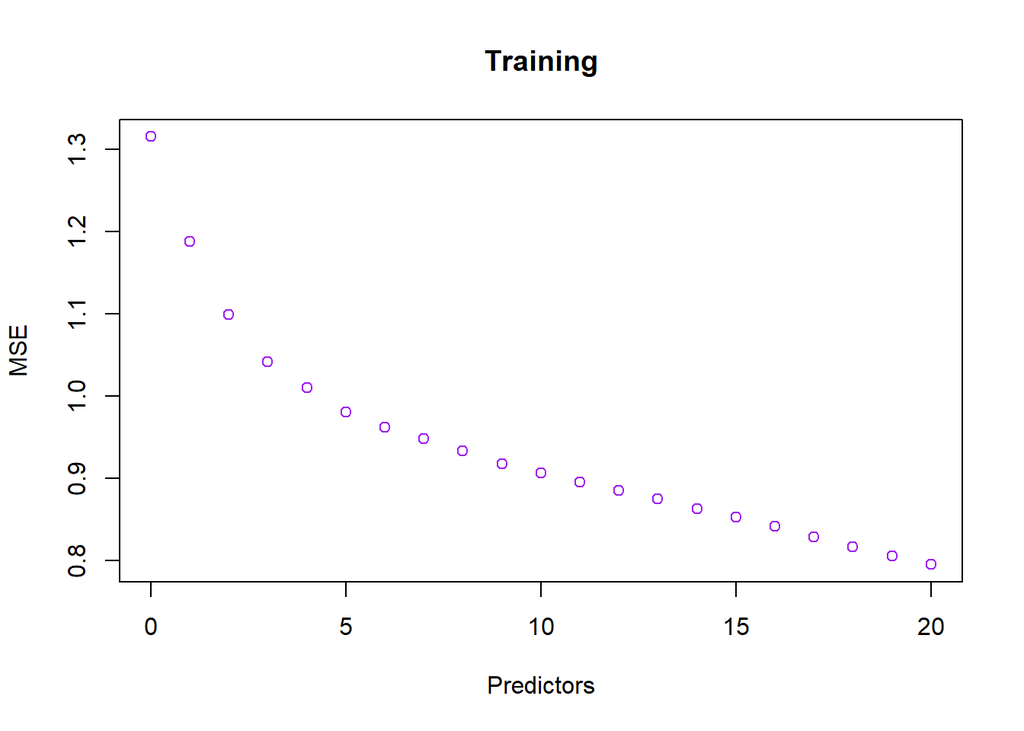

   ```r
   plot(x = 0:p, y = mean_train_mse,
        xlab = "Predictors", ylab = "MSE",
        main = "Training",
        col = "purple")
   ```

   **Show the starter code**

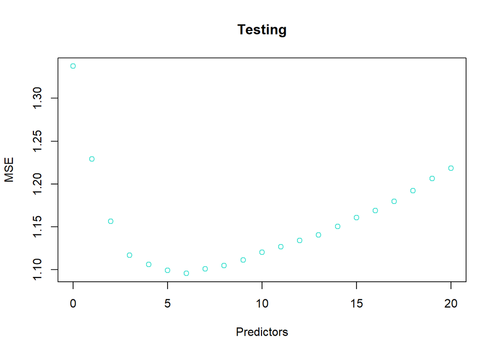

   ```r
   plot(x = 0:p, y = mean_test_mse,
        xlab = "Predictors", ylab = "MSE",
        main = "Testing",
        col = "turquoise")
   ```

   Verifying for training MSE that it does not increase as predictors are added.

   **Show the starter code**

   ```r
   as.data.frame(mean_train_mse) %>%
     mutate(number_predictors = 1:21) %>%
     select(number_predictors, mean_train_mse) %>%
     arrange(mean_train_mse)
   ```

   ```
      number_predictors mean_train_mse
   1                 21      0.7952498
   2                 20      0.8057868
   3                 19      0.8171447
   4                 18      0.8284213
   5                 17      0.8414122
   6                 16      0.8528549
   7                 15      0.8630142
   8                 14      0.8747889
   9                 13      0.8850421
   10                12      0.8952180
   11                11      0.9063967
   12                10      0.9175303
   13                 9      0.9330141
   14                 8      0.9483926
   15                 7      0.9624284
   16                 6      0.9806616
   17                 5      1.0108107
   18                 4      1.0419479
   19                 3      1.0988476
   20                 2      1.1883640
   21                 1      1.3157144
   ```

2. For the model containing the first $j$ predictors, write

$$\mathbf Z_j
=
[\mathbf 1,\mathbf x_1,\ldots,\mathbf x_j],
\qquad
\mathbf H_j
=
\mathbf Z_j
(\mathbf Z_j^{\mathsf T}\mathbf Z_j)^{-1}
\mathbf Z_j^{\mathsf T}.$$

Let $d_j=j+1$ be its fitted mean-parameter count, including the intercept. Define its **total squared approximation bias** as

$$B_j^2
=\left\lVert
(\mathbf I_n-\mathbf H_j)\boldsymbol\mu
\right\rVert_2^2.$$

Thus, $B_j^2/n$ is the mean squared approximation bias.

Calculate the two theoretical expectations

$$E\!\left(
\operatorname{MSE}_{\mathrm{train},j}
\mid \mathbf X
\right)
=\frac{B_j^2}{n}+1-\frac{d_j}{n},$$

and

$$E\!\left(
\operatorname{MSE}_{\mathrm{test},j}
\mid \mathbf X
\right)
=\frac{B_j^2}{n}+1+\frac{d_j}{n}.$$

Add these expectations to your plot and compare them with the simulation averages.

**Show the starter code**

```r
d = p + 1
bias_mse = numeric(p + 1)
bias_mse[1] = mean((mu - mean(mu))^2)

for (j in 1:p) {
  mean_data = data.frame(mu = mu, X[, 1:j, drop = FALSE])
  mean_fit = lm(mu ~ ., data = mean_data)
  bias_mse[j + 1] = mean(residuals(mean_fit)^2)
}

theory_train_mse = bias_mse + (1 - d / n) * sigma^2
theory_test_mse = bias_mse + (1 + d / n) * sigma^2

theory_train_mse = numeric(p + 1)
theory_test_mse = numeric(p + 1)

for(j in 0:p){
d_j = j + 1

theory_train_mse[j + 1] = bias_mse[j + 1] + 1 - d_j/n
theory_test_mse[j + 1] = bias_mse[j + 1] + 1 + d_j/n
}
```

**Show the starter code**

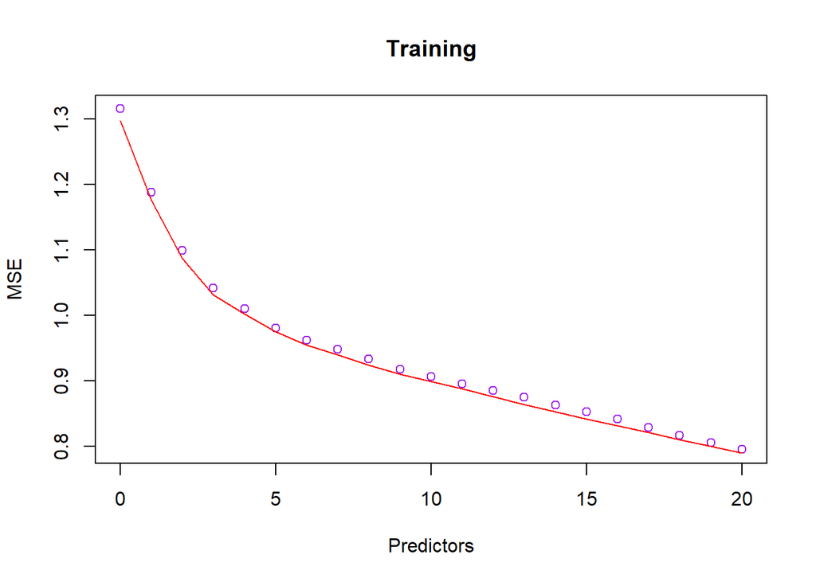

```r
plot(x = 0:p, y = mean_train_mse,
     xlab = "Predictors", ylab = "MSE",
     main = "Training",
     col = "purple")
lines(x = 0:p, y = theory_train_mse, col = "red")
```

**Show the starter code**

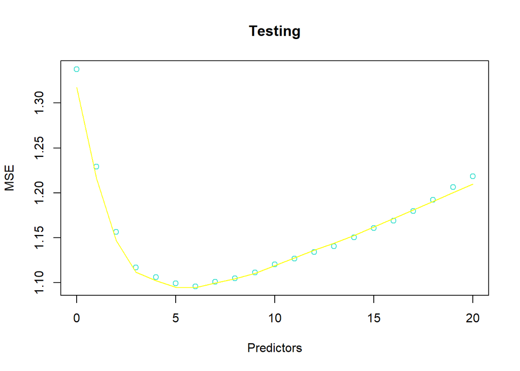

```r
plot(x = 0:p, y = mean_test_mse,
     xlab = "Predictors", ylab = "MSE",
     main = "Testing",
     col = "turquoise")
lines(x = 0:p, y = theory_test_mse, col = "yellow")
```

3. Add the test MSE curve from one simulation run to the plot. Explain why this single curve is less smooth than the average test MSE. Use the approximation-bias and estimation-variance terms in the expected test MSE to explain why training MSE cannot be used by itself to select the predictor count.

   **Show the starter code**

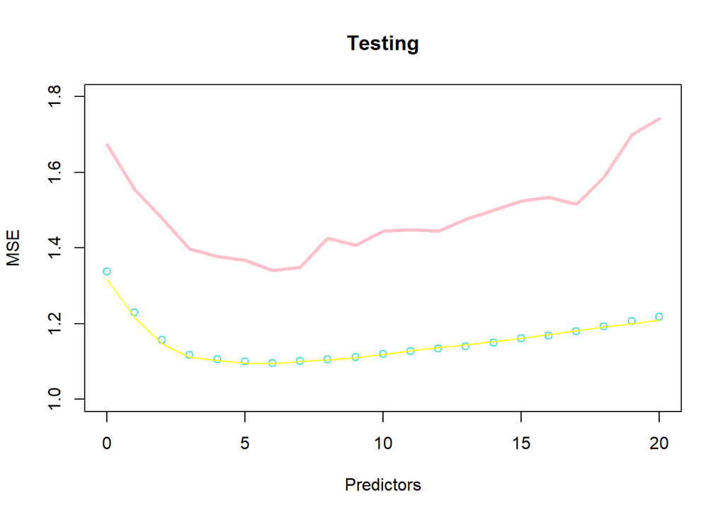

   ```r
   one_run = test_mse[1,]
   plot(x = 0:p, y = mean_test_mse,
        ylim = c(1.0,1.8),
        xlab = "Predictors", ylab = "MSE",
        main = "Testing",
        col = "turquoise")
       lines(x = 0:p, y = one_run, col = "pink", lwd = 3)
       lines(x = 0:p, y = theory_test_mse, col = "yellow")
   ```

The average looks at all of the simulation runs and finds a smooth line that will fit them as best as possible, whereas one single run has no such guarantees. We can see that it follows the teal points of the average roughly though, just in a more jagged way.

We cannot use the training MSE to select the number of predictors because of the optimism. The training error will be too small (aka overly optimistic) because the estimation variance gets subtracted instead of added, like in the testing error.

Corrections from Solutions: I should have made sure that the training error decreased in every simulation instead of just looking at averages. I also had an error of d in the code which was making my graphs look more messed up than they should have.

## Question 2: Prediction error at one target point

Let $n=100$, $p=6$, and $\sigma^2=1$. Construct the fixed matrix $\mathbf X\in\mathbb R^{n\times p}$ with entries

$$X_{ik}
=\sqrt{2}\cos\left\{
\frac{\pi k(i-\tfrac12)}{n}
\right\},
\qquad
i=1,\ldots,n,
\quad
k=1,\ldots,p.$$

Its columns satisfy

$$\mathbf 1^{\mathsf T}\mathbf X=\mathbf 0^{\mathsf T},
\qquad
\frac{1}{n}\mathbf X^{\mathsf T}\mathbf X=\mathbf I_p.$$

Here $\mathbf I_p$ is the $p\times p$ identity matrix.

The following code shows a direct construction of $\mathbf X$.

**Show the starter code**

```r
n = 100
p = 6
X = outer(
  1:n, 1:p,
  function(i, k) sqrt(2) * cos(pi * k * (i - 0.5) / n)
)
```

Keep $\mathbf X$ fixed and generate one training response from

$$\mathbf y
=\mathbf X\boldsymbol\beta+\boldsymbol\epsilon,
\qquad
\boldsymbol\beta
=(0.5,0.5,0.5,0.5,0.5,0.5)^{\mathsf T},$$

where

$$\boldsymbol\epsilon
\sim
\mathcal N_n(\mathbf 0,\mathbf I_n).$$

Here $\mathbf I_n$ is the $n\times n$ identity matrix.

**Show the starter code**

```r
beta = matrix(data = c(0.5,0.5,0.5,0.5,0.5,0.5), nrow = 6, ncol = 1)
e = rnorm(n, 0, 1)
y = X %*%beta + e
```

For $j=0,\ldots,6$, fit a linear model with an intercept and the first $j$ predictors. Consider prediction of the mean response at

$$\mathbf x_0=(0,1,0,0,1,0)^{\mathsf T}.$$

Write

$$\mu_0=\mathbf x_0^{\mathsf T}\boldsymbol\beta,$$

and let $\widehat\mu_{0,j}$ be the prediction from the model containing the first $j$ predictors. Here $x_{0k}$ denotes the $k$th coordinate of $\mathbf x_0$. For this design,

$$E\!\left[
\left(\widehat\mu_{0,j}-\mu_0\right)^2
\mid \mathbf X
\right]
=
\left(
\sum_{k=j+1}^{p}x_{0k}\beta_k
\right)^2
+\frac{\sigma^2}{n}
\left(
1+\sum_{k=1}^{j}x_{0k}^2
\right).$$

1. Calculate $\mu_0$ and the theoretical expected squared error for $j=0,\ldots,6$. Identify the values of $j$ where this error changes and where it remains unchanged.

   $\mu_0$ is 1, and the theoretical expected squared error is 0.03. The bias decreases when j = 2 because then there is less bias, and then the bias is eliminated when j = 5 because all of the useful predictors have been incorporated.
2. Use seed `43203`. Generate the response, fit the models, and calculate

$$\left(\widehat\mu_{0,j}-\mu_0\right)^2.$$

Repeat this independently 200 times. Plot the simulation averages and theoretical expectations together. Report the smallest $j$ that minimizes the theoretical error.

**Show the starter code**

```r
set.seed(43203)

nsim = 200
sqerr = matrix(NA, nrow = nsim, ncol = 7)
mu0 = 1
x0 = c(0, 1, 0, 0, 1, 0)

for (s in 1:nsim) {
  eps = rnorm(n, mean = 0, sd = 1)
  y = X %*% beta + eps
  for (j in 0:6) {
    if (j == 0) {
      muhat = mean(y)
    } else {
      Xj = X[, 1:j, drop = FALSE]
      Zj = cbind(1, Xj)
      bhat = solve(t(Zj) %*% Zj) %*% t(Zj) %*% y
      z0 = c(1, x0[1:j])
      muhat = as.numeric(z0 %*% bhat)
    }
    sqerr[s, j + 1] = (muhat - mu0)^2
  }
}
```

**Show the starter code**

```r
theorymaybe = c(1.01,1.01,0.27, 0.27,0.27,0.03,0.03)
```

**Show the starter code**

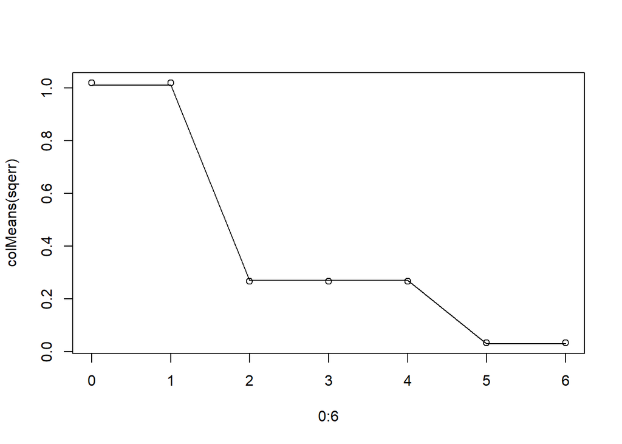

```r
plot(0:6, colMeans(sqerr))
lines(0:6, theorymaybe)
```

The smallest j where they line up is j = 5.

3. All six regression coefficients are nonzero. Explain why only predictors 2 and 5 contribute directly to the mean response at $\mathbf x_0$. Contrast this target-specific error with the test MSE averaged over all rows of $\mathbf X$ in Question 1.

   Only predictors 2 and 5 contributed when $x_0$ was calculated because of the $x_0$ values. Even though $\beta$ is nonzero, all of $x_0$ is besides 2 and 5, so those are the predictors that contribute. This is different from the first question because we were not able to truly average over all of the rows since some of the values cancelled out.

Notes from Solutions:

Technically could have expanded table in part a, expected error went from 1.01 to 0.03 and Bias went from 1.00 to 0, etc.

My theorymaybe vector was incorrect, added the wrong column from part A. Second part of B, they wanted it as the “smallest minimum theoretical error” which is what I meant. “A predictor can matter for average prediction even when it does not contribute at one particular target.”

## Question 3: The optimism correction

Choose one candidate model before observing the response. Let $\mathbf Z\in\mathbb R^{n\times d}$ be its full-rank design matrix, including the intercept, and let

$$\mathbf H
=\mathbf Z
(\mathbf Z^{\mathsf T}\mathbf Z)^{-1}
\mathbf Z^{\mathsf T}$$

be its hat matrix. Suppose

$$\mathbf y=\boldsymbol\mu+\boldsymbol\epsilon,
\qquad
\mathbf y^*=\boldsymbol\mu+\boldsymbol\epsilon^*,$$

Conditional on the fixed design $\mathbf Z$, the two error vectors are independent, have mean zero, and have covariance matrix $\sigma^2\mathbf I_n$. Define

$$\operatorname{MSE}_{\mathrm{train}}
=
\frac{1}{n}
\left\lVert
\mathbf y-\mathbf H\mathbf y
\right\rVert_2^2,
\qquad
\operatorname{MSE}_{\mathrm{test}}
=
\frac{1}{n}
\left\lVert
\mathbf y^*-\mathbf H\mathbf y
\right\rVert_2^2.$$

The conditional bias vector of the fitted mean is

$$E(\mathbf H\mathbf y\mid\mathbf Z)-\boldsymbol\mu
=
-(\mathbf I_n-\mathbf H)\boldsymbol\mu.$$

Let $B^2$ denote the **total squared approximation bias**:

$$B^2
=\left\lVert
(\mathbf I_n-\mathbf H)\boldsymbol\mu
\right\rVert_2^2.$$

Thus, $B^2/n$ is the mean squared approximation bias.

You may use

$$\mathbf H^{\mathsf T}=\mathbf H,
\qquad
\mathbf H^2=\mathbf H,
\qquad
\operatorname{tr}(\mathbf H)=d.$$

For any fixed matrix $\mathbf A$, you may also use

$$E\!\left(
\boldsymbol\epsilon^{\mathsf T}
\mathbf A
\boldsymbol\epsilon
\mid \mathbf Z
\right)
=\sigma^2\operatorname{tr}(\mathbf A).$$

1. Derive

$$E(\operatorname{MSE}_{\mathrm{train}}\mid\mathbf Z)
=\frac{B^2}{n}
+\sigma^2\left(1-\frac{d}{n}\right),$$

and

$$E(\operatorname{MSE}_{\mathrm{test}}\mid\mathbf Z)
=\frac{B^2}{n}
+\sigma^2\left(1+\frac{d}{n}\right).$$

These were derived on paper since that was simpler.

2. Deduce the expected optimism, defined as $E(\operatorname{MSE}_{\mathrm{test}}-\operatorname{MSE}_{\mathrm{train}}\mid\mathbf Z)$. For

$$n=120,
\qquad
d=5,
\qquad
\frac{B^2}{n}=0.04,
\qquad
\sigma^2=1,$$

calculate the expected training MSE, expected test MSE, and their difference. Explain why the ordering need not hold for every realized pair of responses.

Optimism: $\frac{2p\sigma^2}{n}$

Expected training MSE:

**Show the starter code**

```r
trainingdiff = 0.04 + 1*(1-(5/120))
trainingdiff
```

```
[1] 0.9983333
```

Expected testing MSE:

**Show the starter code**

```r
testdiff = 0.04 + 1*(1+(5/120))
testdiff
```

```
[1] 1.081667
```

Difference:

The order of the difference might not actually be true because the actual data will have variation and not exactly follow the theory, but in general, the average test MSE will be greater than the average train MSE, so we subtract in that order.

**Show the starter code**

```r
testdiff-trainingdiff
```

```
[1] 0.08333333
```

3. Continue with $n=120$ and $d=5$. Suppose the candidate model has residual sum of squares $\operatorname{RSS}=116.4$, and suppose a common estimate of the error variance is $\widehat\sigma^2=0.96$.

Calculate

$$\widehat{\operatorname{MSE}}_{\mathrm{test}}
=\frac{
\operatorname{RSS}+2d\widehat\sigma^2
}{n},$$

and

$$C_p
=\frac{\operatorname{RSS}}{\widehat\sigma^2}
-n+2d.$$

Show how these two quantities are related, and explain why minimizing $C_p$ is equivalent to minimizing the corrected test MSE when $n$ and $\widehat\sigma^2$ are common to all candidate models.

**Show the starter code**

```r
MSE_test = (116.4 + 2*5*0.96)/120
MSE_test
```

```
[1] 1.05
```

**Show the starter code**

```r
Cp = (116.4/0.96)-120+2*5
Cp
```

```
[1] 11.25
```

The two quantities are related because they use the same values, just written in a different form. MSE has a different scale. So, minimizing them would be the same.

From solutions:

b) 2d instead of 2p here for optimism.

c) needed to actually calculate tranformation…

$\frac{\hat\sigma^2(C_p+n)}{n} = \hat{MSE}_{test}$

## Question 4: Comparing Mallows’ $C_p$, AIC, and BIC

Use `data/diabetes.csv`, with `y` as the response. Use rows 1 through 370 as the training data, and let $n=370$ denote the training sample size. Do not use rows 371 through 442 in this question. Fit the following ordinary least-squares models, each with an intercept.

**Show the starter code**

```r
n = 370
```

**Show the starter code**

```r
diabetes = read_csv("C:/Users/sophi/OneDrive/stat432-fall2026/homework/week-02/diabetes.csv")
```

**Show the starter code**

```r
df = diabetes[1:370,]
```

| Model | Predictors | $d$ |
| --- | --- | --- |
| Model A | `bmi`, `bp`, `s5`, `sex`, `s1`, `s2`, `s4` | 8 |
| Model B | all predictors in Model A, followed by `s6` | 9 |
| Full reference | all ten predictors | 11 |

**Show the starter code**

```r
model_a = lm(y ~ bmi + bp + s5 + sex + s1 + s2 + s4, data = df)
model_b = lm(y ~ bmi + bp + s5 + sex + s1 + s2 + s4 + s6, data = df)
model_full = lm(y ~ ., data = df)
```

Here $d$ counts fitted mean parameters, including the intercept. Estimate one common noise variance from the full reference model:

$$\widehat\sigma^2_{\mathrm{full}}
=\frac{\operatorname{RSS}_{\mathrm{full}}}{n-11}.$$

**Show the starter code**

```r
(sum(model_full$residuals^2)/n-11)
```

```
[1] 2933.464
```

For Models A and B, calculate

$$C_p
=\frac{\operatorname{RSS}}{\widehat\sigma^2_{\mathrm{full}}}
-n+2d,$$

$$\operatorname{AIC}^{\mathrm{red}}
=n\log\left(\frac{\operatorname{RSS}}{n}\right)+2d,$$

and

$$\operatorname{BIC}^{\mathrm{red}}
=n\log\left(\frac{\operatorname{RSS}}{n}\right)
+d\log(n).$$

The reduced AIC and BIC omit constants shared by the two candidate models. Smaller values are preferred within each criterion.

1. Fit the three models. Report $d$, RSS, the residual degrees of freedom of the full model, and $\widehat\sigma^2_{\mathrm{full}}$.

   Model A:

   **Show the starter code**

   ```r
   summary(model_a)
   ```

   ```
   Call:
   lm(formula = y ~ bmi + bp + s5 + sex + s1 + s2 + s4, data = df)

   Residuals:
        Min       1Q   Median       3Q      Max
   -157.449  -39.457   -3.017   39.132  150.704

   Coefficients:
               Estimate Std. Error t value Pr(>|t|)
   (Intercept)  152.724      2.865  53.311  < 2e-16 ***
   bmi          542.420     74.009   7.329 1.52e-12 ***
   bp           327.557     70.657   4.636 4.97e-06 ***
   s5           682.370    132.134   5.164 3.99e-07 ***
   sex         -244.708     67.131  -3.645 0.000306 ***
   s1          -587.534    224.755  -2.614 0.009320 **
   s2           328.919    243.576   1.350 0.177739
   s4           138.016    131.893   1.046 0.296066
   ---
   Signif. codes:  0 '***' 0.001 '**' 0.01 '*' 0.05 '.' 0.1 ' ' 1

   Residual standard error: 55.1 on 362 degrees of freedom
   Multiple R-squared:  0.501, Adjusted R-squared:  0.4913
   F-statistic: 51.92 on 7 and 362 DF,  p-value: < 2.2e-16
   ```

   **Show the starter code**

   ```r
   d_a= 8
   RSS_a = sum(model_a$residuals^2)
   df_a = 362
   sigma2_hat_a = RSS_a/df
   ```

Model B:

**Show the starter code**

```r
summary(model_b)
```

```
Call:
lm(formula = y ~ bmi + bp + s5 + sex + s1 + s2 + s4 + s6, data = df)

Residuals:
     Min       1Q   Median       3Q      Max
-154.815  -38.503   -2.393   40.088  149.861

Coefficients:
            Estimate Std. Error t value Pr(>|t|)
(Intercept)  152.689      2.857  53.448  < 2e-16 ***
bmi          526.218     74.382   7.075 7.84e-12 ***
bp           305.248     71.608   4.263 2.58e-05 ***
s5           650.188    133.047   4.887 1.54e-06 ***
sex         -258.614     67.415  -3.836 0.000147 ***
s1          -596.703    224.184  -2.662 0.008123 **
s2           329.736    242.891   1.358 0.175456
s4           121.543    131.861   0.922 0.357273
s6           128.822     73.824   1.745 0.081839 .
---
Signif. codes:  0 '***' 0.001 '**' 0.01 '*' 0.05 '.' 0.1 ' ' 1

Residual standard error: 54.94 on 361 degrees of freedom
Multiple R-squared:  0.5052,    Adjusted R-squared:  0.4942
F-statistic: 46.07 on 8 and 361 DF,  p-value: < 2.2e-16
```

**Show the starter code**

```r
d_b = 9
RSS_b = sum(model_b$residuals^2)
df_b = 361
sigma2_hat_b = RSS_b/df
```

Full Model:

**Show the starter code**

```r
summary(model_full)
```

```
Call:
lm(formula = y ~ ., data = df)

Residuals:
     Min       1Q   Median       3Q      Max
-154.413  -37.799   -2.672   40.097  151.509

Coefficients:
            Estimate Std. Error t value Pr(>|t|)
(Intercept)  152.679      2.865  53.285  < 2e-16 ***
age           16.868     65.360   0.258 0.796499
sex         -259.836     68.077  -3.817 0.000159 ***
bmi          526.005     74.584   7.053 9.08e-12 ***
bp           302.234     72.980   4.141 4.31e-05 ***
s1          -652.710    471.593  -1.384 0.167202
s2           367.175    385.969   0.951 0.342088
s3            31.009    240.535   0.129 0.897496
s4           139.019    177.161   0.785 0.433146
s5           666.942    192.956   3.456 0.000613 ***
s6           126.163     74.597   1.691 0.091657 .
---
Signif. codes:  0 '***' 0.001 '**' 0.01 '*' 0.05 '.' 0.1 ' ' 1

Residual standard error: 55.09 on 359 degrees of freedom
Multiple R-squared:  0.5053,    Adjusted R-squared:  0.4915
F-statistic: 36.67 on 10 and 359 DF,  p-value: < 2.2e-16
```

**Show the starter code**

```r
d = 11
RSS = sum(model_full$residuals^2)
df = 359
sigma2_hat = RSS/df
```

2. Calculate $C_p$, reduced AIC, and reduced BIC for Models A and B. State which model each criterion selects. Do not compare numerical values across different criteria.

   Model A:

   **Show the starter code**

   ```r
   Cp_A = (RSS_a/sigma2_hat)-n+2*d_a
   Cp_A
   ```

   ```
   [1] 8.116253
   ```

   **Show the starter code**

   ```r
   AIC_A = n*log(RSS_a/n)+2*d_a
   AIC_A
   ```

   ```
   [1] 2974.64
   ```

   **Show the starter code**

   ```r
   BIC_A = n*log(RSS_a/n)+d_a*log(n)
   BIC_A
   ```

   ```
   [1] 3005.948
   ```

   Model B:

   **Show the starter code**

   ```r
   Cp_B = (RSS_b/sigma2_hat)-n+2*d_b
   Cp_B
   ```

   ```
   [1] 7.087434
   ```

   **Show the starter code**

   ```r
   AIC_B = n*log(RSS_b/n)+2*d_b
   AIC_B
   ```

   ```
   [1] 2973.532
   ```

   **Show the starter code**

   ```r
   BIC_B = n*log(RSS_b/n)+d_b*log(n)
   BIC_B
   ```

   ```
   [1] 3008.754
   ```

   $C_p$ and AIC select Model B, and BIC selects Model A.
3. Compare the improvement in fit from adding `s6` with the one-parameter penalty under each criterion. Use this comparison to explain any disagreement. Why does selecting a model not establish that it is the true data-generating model?

   This makes sense because Model B is a larger model, so BIC does not favor it, which is why BIC prefers Model A. However, $C_p$ and AIC find that the improvement in fit from adding s6 is in fact worth it. Selecting a model doesn’t establish that it is the true data-generating model because we have not tried every possible model ever, and it also depends on our larger real-world context.

notes from solutions:

## Question 5: Validation and final test data

Use rows 1 through 370 of `diabetes.csv` as the training data and rows 371 through 442 as the final test data. Consider eleven nested candidate models. For $j=0,1,\ldots,10$, the model with $j$ predictors contains an intercept and the first $j$ predictors in this order:

`age`, `sex`, `bmi`, `bp`, `s1`, `s2`, `s3`, `s4`, `s5`, `s6`.

An analyst proposes the following procedure:

1. Fit all eleven candidate models using the training data.
2. Calculate the MSE of each model on the final test data.
3. Select the model with the smallest test MSE.
4. Report that minimum as the final estimate of prediction error.

The analyst argues that the procedure is valid because the final test data were not used to estimate the regression coefficients.

1. Identify the first step that misuses the final test data. Explain why the minimum of eleven test MSE values is generally too favorable as an estimate of the selected procedure’s future prediction error.

   You can’t use the test data to select what parameters are used in the final model. The model must be selected from only the training data, and then it is used with the test data after that. If you train it off of test data, then when you put unseen values into the model, then it won’t be fully prepared.
2. Rewrite the analysis using five-fold cross-validation within the training data. State how the predictor count is selected, what is refitted, and when the final test data may be used.

   **Show the starter code**

   ```r
   library(caret)
   ```

   **Show the starter code**

   ```r
   diabetes = read_csv("C:/Users/sophi/OneDrive/stat432-fall2026/homework/week-02/diabetes.csv")
   ```

   **Show the starter code**

   ```r
   df = diabetes[1:370, ]
   ```

   **Show the starter code**

   ```r
   formulas = list(
     y ~ age,
     y ~ age + sex,
     y ~ age + sex + bmi,
     y ~ age + sex + bmi + bp,
     y ~ age + sex + bmi + bp + s1,
     y ~ age + sex + bmi + bp + s1 + s2,
     y ~ age + sex + bmi + bp + s1 + s2 + s3,
     y ~ age + sex + bmi + bp + s1 + s2 + s3 + s4,
     y ~ age + sex + bmi + bp + s1 + s2 + s3 + s4 + s5,
     y ~ age + sex + bmi + bp + s1 + s2 + s3 + s4 + s5 + s6
   )


   control_parameters = trainControl(method = "cv", number = 5)
   model_cv = lapply(formulas, function(f) {
     train(
       f,
       data = df,
       method = "lm",
       trControl = control_parameters
     )
   })
   ```

   **Show the starter code**

   ```r
   class(df)
   ```

   ```
   [1] "tbl_df"     "tbl"        "data.frame"
   ```

   **Show the starter code**

   ```r
   cv_results = data.frame(j = 1:10,
                           RMSE = sapply(model_cv, function(model) model$results$RMSE))
   cv_results
   ```

   ```
       j     RMSE
   1   1 75.94046
   2   2 76.37084
   3   3 63.22354
   4   4 60.96916
   5   5 60.68524
   6   6 60.67979
   7   7 56.64427
   8   8 56.83733
   9   9 55.44165
   10 10 55.82092
   ```

   **Show the starter code**

   ```r
   cv_results$j[which.min(cv_results$RMSE)]
   ```

   ```
   [1] 9
   ```

   **Show the starter code**

   ```r
   folds = createFolds(df$y, k = 5, list = TRUE)
   rmse_0 = sapply(folds, function(test_indices) {

     train_fold = df[-test_indices, ]
     test_fold  = df[test_indices, ]

     model0 = lm(y ~ 1, data = train_fold)

     predictions = predict(model0, newdata = test_fold)

     sqrt(mean((test_fold$y - predictions)^2))
   })

   rmse_0 = mean(rmse_0)
   cv_results = rbind(data.frame(j = 0, RMSE = rmse_0), cv_results)
   cv_results
   ```

   ```
       j     RMSE
   1   0 77.12848
   2   1 75.94046
   3   2 76.37084
   4   3 63.22354
   5   4 60.96916
   6   5 60.68524
   7   6 60.67979
   8   7 56.64427
   9   8 56.83733
   10  9 55.44165
   11 10 55.82092
   ```

   **Show the starter code**

   ```r
   best_j = cv_results$j[which.min(cv_results$RMSE)]
   best_j
   ```

   ```
   [1] 9
   ```

   The predictor count is selected after running the kfolds cross validation and seeing what the minimum RMSE is (with only using the training data). Then, refit the selected model parameters with all of the training data. Last, then the final test data can be used.

   **Show the starter code**

   ```r
   selected_model = lm(y~age + sex + bmi + bp + s1 + s2 + s3 + s4 + s5, data = df)
   test_df = diabetes[371:442,]
   ```

   **Show the starter code**

   ```r
   test_predict = predict(selected_model, newdata = test_df)
   test_rmse = sqrt(
     mean((test_df$y - test_predict)^2)
   )

   test_rmse
   ```

   ```
   [1] 48.67591
   ```

3. Suppose the analyst has already examined all eleven test MSE values. What can still be reported transparently, and what additional data would be needed for a new final evaluation?

   You can understand that for that specific model fitting, those would be the MSE values, but you would need to fit the model on the training data to have a proper evaluation. It needs to be tested independently, either way.

Notes from solutions:

b) preprocessing must be estimated inside each training fold (concept that didn’t actually occur)

c) Cannot claim that the minimum test MSE is unbiased, use independent test data (what I was meaning)

## Reference

James, Witten, Hastie, Tibshirani, and Taylor, [*An Introduction to Statistical Learning*](https://www.statlearning.com/), Chapters 3, 5, and 6.